# Decision Trees to Predict Wins

## Exposition

This work will be using a dataset about a specific professional eSport called Dota 2. It is considered one of the greatest games designed and is compared to the strategic titans like Chess and Go. OpenAI released an AI model to mimic player behavior and to compete against professionals similar to famours machines like Deep Blue or the more recent Komodo Dragon 3 and Fat Fritz 2. Dota 2 has a long and rich history akin to the best of college sports rivalries. It currently holds the top 7 highest prize pools topping out at $40 million dollars, it also has an active betting scene.  
A quick summary on how Dota 2 is played is required for better understanding of the data. Dota 2 is a 5v5 game played on a square map with 3 ‘lanes’ serving as the main connection between players. Each player chooses 1 of these 3 lanes and fights over gaining gold to purchase items to assist in killing the enemy and ultimately destory the opponents’ base. Each player chooses 1 of 100+ heroes, each with their own unique abilities and play styles, to compete against each other. My favorite hero to play right now is Nature’s Prophet and **this analysis will be focused on what variables can be used to predict whether he wins or not.**  
Nature’s Prophet is a hero with abilities that focus on having a global presence to support teammates, and using summoned units to deal damage to enemy buildings. As you can imagine, that may influence certain predictive variables to be more impactful than other heroes. The data used in this analysis have all been sourced from OpenDota which provides real data from real matches. The patch and date time of the data will relate to when Nature’s Prophet was considered at his strongest in patch 7.31d.  
The variables used are all stats from the games themselves. A list and short description of them are below.

**1. gold_per_min** | Sometimes shortened to GPM, gold per minute represents how much gold a hero was accuring every minute. This metric can change throughout the game and is a hybrid measurement between a hero’s power and player efficiency. A higher GPM means you’re likely strong and efficient.

**2. net_worth** | Another measure of gold, net worth is the final amount of gold a hero is worth at the end of the game. Gold can be spent on items, most appopriately thought of as assets, as well as consumables which disappear after use. Net worth is the ‘gold’ standard to measure a hero’s power in the game.

**3. gold** | Although it may seem redundant, gold here is just the amount of gold the player had left at the end of the game. Sometimes players are saving for a big item that they hope will change the next fight, other times they get it just in time and have no money left to buy a second life after they die.

**4. kills** | This variable is a count of kills. The more kills a hero has, the more gold they would have, but it also is a representation of how much impact they had on a game. Some heros thrive on killing other heros, where some want to avoid fighting and killing for quite some time.

**5. tower_damage** | This variable indicates how much damage a hero caused to the enemy buildings. Some heros excel at destroying buildings rather than killing.. sometimes they’re good at both!

**6.duration** Duration represents how long the game went in the format of ‘mmss’, i.e. 2412 is a 24 minutes 12 second game. Some heros are more powerful as the game goes on, while others depend on ending the game early.

**7. lane** | Lanes are symmetrical between teams, but each lane within a team is different from another. Lane 1, the ‘safelane’ is typically meant for gold dependent heros. Lane 2, the ‘midlane’ is good for heros that do well in 1v1 scenarios and scale well with both xp and gold. Lane 3, the ‘offlane’ is typically saved for highly survivable heros that provide utility to the team with little gold and experience.

**8. lane_role** | Across lanes, a team is divided up into farm priorities to identify who should be taking the available gold. This is denoted by the numbers 1 - 5 with 1 being the most important and 5 being the least important. Its best to interpret this as an indicator of farm level within their team. i.e. A value of 1 would indicate they were the most farmed on their team.

```r
#Load in data and format correctly
    npData<-read_csv("NPBase.csv")
    npData$gold <- as.numeric(npData$gold)
    dataModel <- data.frame(npData)
    dataModel$win <- as.factor(dataModel$win)
    dataModel$lane <- as.factor(dataModel$lane)
    dataModel$lane_role <- as.factor(dataModel$lane_role)
    paged_table(dataModel)
```

| match_id | start_time | win | hero_id | account_id | leaguename | gold_per_min | net_worth | gold | kills | tower_damage | duration | lane | lane_role |
| --- | --- | --- | --- | --- | --- | --- | --- | --- | --- | --- | --- | --- | --- |
| 6653637943 | 1657339909 | FALSE | 53 | 250544263 | Titus Colosseum Cup | 569 | 15770 | 1140 | 3 | 1221 | 1754 | 1 | 3 |
| 6653911377 | 1657357190 | FALSE | 53 | 76082922 | Destiny league | 549 | 15317 | 892 | 3 | 1559 | 1794 | 1 | 3 |
| 6654090150 | 1657366555 | TRUE | 53 | 1312740399 | Ultras Dota Pro League | 654 | 16985 | 3210 | 10 | 19823 | 1547 | 3 | 3 |
| 6656721191 | 1657512120 | FALSE | 53 | 209165399 | Titus Colosseum Cup | 472 | 10399 | 449 | 4 | 1264 | 1319 | 1 | 1 |
| 6657130147 | 1657540852 | TRUE | 53 | 132851371 | Dota 2 Champions League 2021-2022 Season | 894 | 40098 | 9648 | 10 | 28469 | 2938 | 3 | 1 |
| 6657972166 | 1657586272 | TRUE | 53 | 59752811 | Thunderpick Bitcoin Series | 593 | 21647 | 6622 | 5 | 10388 | 2435 | 3 | 1 |
| 6658023411 | 1657591653 | FALSE | 53 | 85367644 | Thunderpick Bitcoin Series | 442 | 11580 | 2130 | 0 | 11727 | 1846 | 1 | 1 |
| 6658141348 | 1657602904 | FALSE | 53 | 1312740399 | Ultras Dota Pro League | 434 | 9842 | 1192 | 0 | 6657 | 1315 | 3 | 3 |
| 6658904045 | 1657643886 | TRUE | 53 | 155370747 | Dota 2 Champions League 2021-2022 Season | 701 | 26720 | 4570 | 9 | 18541 | 2332 | 1 | 3 |
| 6659582275 | 1657695291 | TRUE | 53 | 412910858 | Destiny league | 752 | 24276 | 2576 | 13 | 9039 | 2263 | 3 | 3 |

[output cut: 188 more lines]

## EDA

### 5 Number Summary

From experience playing, it is clear there are few special features in the 5 Number Summary that are unique to Nature’s Prophet. The averages for gold_per_min are higher than most other heroes, normally being around 550. Net_worth is also higher than most as this metric across heroes is typically at 17,000 to 18,000. Gold is roughly the same compared to other heroes. Tower_damage is a somewhat higher than most heroes as many sit around 8,000 or less. Duration of games is quite low at 20 minutes. Per OpenDota documentation, the numbers are read as the first two numbers being minutes and the last two numbers being seconds. Most games normally last about 30 minutes, whereas with Nature’s Prophet the games average out at 2012 and the median being even smaller at 19 minutes.

```r
summary(dataModel[,-c(1,2,4,5,6,13,14)])
```

```
##     win       gold_per_min     net_worth          gold          kills
##  FALSE: 88   Min.   :120.0   Min.   : 6108   Min.   :   1   Min.   : 0.000
##  TRUE :110   1st Qu.:560.0   1st Qu.:14357   1st Qu.:1040   1st Qu.: 3.000
##              Median :644.5   Median :19109   Median :1778   Median : 6.000
##              Mean   :644.1   Mean   :20283   Mean   :2263   Mean   : 6.753
##              3rd Qu.:755.0   3rd Qu.:24529   3rd Qu.:2993   3rd Qu.: 9.000
##              Max.   :948.0   Max.   :42703   Max.   :9648   Max.   :22.000
##   tower_damage      duration
##  Min.   :    0   Min.   : 800
##  1st Qu.: 4759   1st Qu.:1614
##  Median : 9044   Median :1908
##  Mean   :10066   Mean   :2012
##  3rd Qu.:15002   3rd Qu.:2326
##  Max.   :28469   Max.   :3667
```

### Histograms

```r
createVariableHistograms <- function(data, var_list, response_var) {
  #Creates a histogram of discrete variables colored by categories of response variable
#Arguments:
  #data: takes a dataframe
  #var_list: accepts a list of strings of variables
  #outcome_var: accepts a string of the variable name

  # Initialize an empty list to store plots
  plot_list <- list()

  for (var in var_list) {
    p <- ggplot(data, aes_string(x = var, color = response_var, fill = "win")) +
      geom_histogram(alpha = 0.5, position = "identity") +
      scale_color_manual(values = c("#999999", "#E69F00", "#56B4E9")) +
      scale_fill_manual(values = c("#999999", "#E69F00", "#56B4E9")) +
      labs(x = paste0("Amount of ", tools::toTitleCase(var)), y = "Count of Matches",
           title = paste0("Matches vs ", tools::toTitleCase(var))) +
      theme_classic()

    # Add the plot to the list
    plot_list[[var]] <- p
  }

  return(plot_list)
}
```

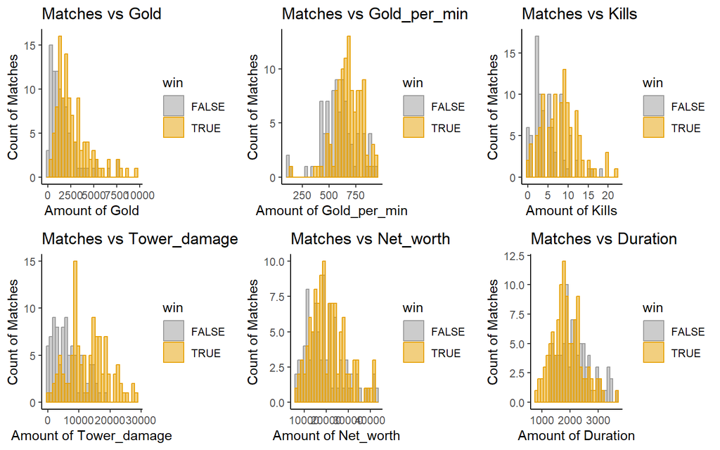

```r
var_list <- c("gold", "gold_per_min", "kills", "tower_damage","net_worth","duration")
response_var <- "win"
plots <- createVariableHistograms(npData, var_list, response_var)

#print the plots using cowplot
plot_grid(plotlist = plots)
```

In relation to winning, the variables that have their distributions higher in value are net_worth, tower_damage, kills, gold_per_min, and gold. Only duration tends to have a distribution closer to 0, which matches our previous observations. It is important to note that for gold and kills, the distributions for winning and losing are relatively close, suggesting that these may not be important variables.

### Boxplots

```r
createVariableBoxplots <- function(data, var_list, response_var) {
  #Creates a boxplot of discrete variables colored by categories of response variable for each variable passed to it
  #Designed to return a list of plots to be given to cowplot's plot_grid function

#Arguments:
  #data: takes a dataframe
  #var_list: accepts a list of strings of variables
  #outcome_var: accepts a string of the variable name

  # Initialize an empty list to store plots
  plot_list <- list()

  # Loop to create boxplots
  for (var in var_list) {
    p <- ggplot(npData,
                 aes_string(y = var,
                 x = response_var,
                 color = response_var),
      fill = response_var)+
      geom_point(size = 0.8) +  #Add points for observations
      geom_boxplot(lwd = 0.5, width = 0.5, #Create boxplot
                    outlier.size = 0.8,
                    alpha = 0.7) +
      labs(title=paste0(tools::toTitleCase(var)," vs ", tools::toTitleCase(response_var)), #title
           xlab(tools::toTitleCase(response_var)),#xlabel
           ylab(tools::toTitleCase(var))) + #ylabel
      #Color section
      scale_color_manual(values=c("#999999", "#E69F00", "#56B4E9")) +
      scale_fill_manual(values=c("#999999", "#E69F00", "#56B4E9")) +
      theme_classic() #classic theme

    plot_list[[var]] <- p
  }
  return(plot_list)
}
```

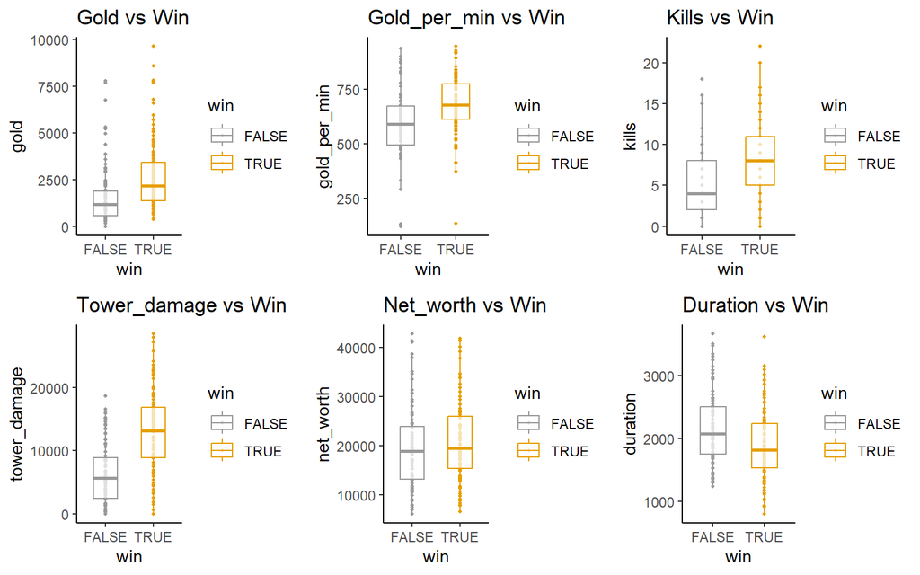

```r
plots <- createVariableBoxplots(npData, var_list, response_var)

#print the plots using cowplot
plot_grid(plotlist = plots)
```

Again we see that duration is the only distribution with wins having a lower distribution than losses. Net_worth is relatively close as is gold and gold_per_min. The difference in wins and losses in terms of kills is actually highlighted here in contrast to the histograms, highlighting the importance of viewing data in several forms.

The code below functions, but there were so many variables it was too much and a correlation plot was created instead.

```r
createVariableScatterplots <- function(data, var_list, response_var) {
  # Create scatterplots for combinations of two variables in var_list

  # Initialize an empty list to store plots
  plot_list <- list()

  # Loop through variable combinations
  for (i in 1:(length(var_list) - 1)) {
    for (j in (i + 1):length(var_list)) {
      var_x <- var_list[i]
      var_y <- var_list[j]

      p <- ggplot(data,
                  aes_string(x = var_x,
                             y = var_y,
                             color = response_var),
                  fill = response_var) +
        geom_point(size = 2) +
        labs(
          title = paste(var_x, " vs ", var_y),
          x = var_x,
          y = var_y
        ) +
        scale_color_manual(values=c("#999999", "#E69F00", "#56B4E9"))+
        scale_fill_manual(values=c("#999999", "#E69F00", "#56B4E9"))+
        theme_minimal()

      # Add the plot to the list
      plot_list[[paste(var_x, var_y, sep = "_")]] <- p
    }
  }

  return(plot_list)
}

# Example usage:
var_list <- c("gold", "gold_per_min", "kills", "tower_damage", "duration","net_worth")
scatterplots <- createVariableScatterplots(npData, var_list,response_var)

# Arrange and print the scatterplots using cowplot
plot_grid(plotlist = scatterplots, ncol = 2)
```

### Correlations

Checking correlation between variables, if looking at wins we see the most notable win factor being tower_damage and a negative relationship with duration. In general, both kills and tower damage have strong relationships with gold_per_min and networth.

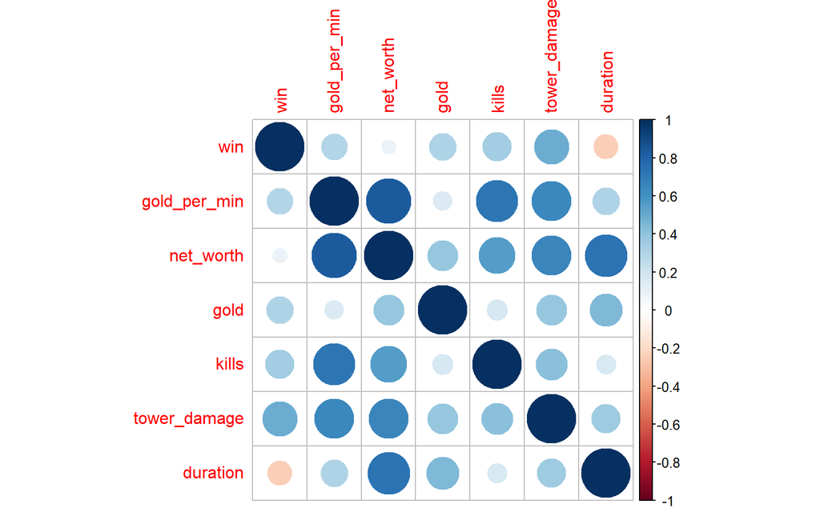

```r
dataModelCorr <- dataModel
dataModelCorr <- dataModelCorr[,-c(1,2,4,5,6,13,14)]
dataModelCorr$win <- as.numeric(dataModel$win)
correlation_matrix <- cor(dataModelCorr)

corrplot(correlation_matrix)
```

## Modeling

Two trees will be created to show differences in variance to hopefully highlight one of the weaknesses of Decision Trees. Each tree will have a different set of variables. The third and final model, a random forest, will also be created to highlight how the random forest can address certain issues with decision trees. Decision trees are typically not the best choice with many predictors or overly powerful predictors. The reason for this is that decision trees will over-fit based on the overly strong variable due to selecting the most powerful variable first to create a prediction. Random forests attempt to manage this by making many shorter trees using only a subset of the predictors. After creating many shorter trees, the “forest”, it will average across them to generate a prediction. Random forests lose their interpretability and typically aren’t viewed due to difficulty of viewing many trees and how the model averages across them.

### Decision Tree 1

Tree 1 will be using four variables. Gold_per_min, kills, net_worth, and gold. From the plots earlier this is expected to be weak since there was low correlation between win and the variables.

```r
#colnames(dataModel)

#Create first set of variables
keepVars <- c("gold_per_min","kills","net_worth","gold","win")

#Select only columns that match our set of variables
dataModel_sub1 <- dataModel[, names(dataModel) %in% keepVars]
paged_table(dataModel_sub1) #Check our dataframe
```

| win | gold_per_min | net_worth | gold | kills |
| --- | --- | --- | --- | --- |
| FALSE | 569 | 15770 | 1140 | 3 |
| FALSE | 549 | 15317 | 892 | 3 |
| TRUE | 654 | 16985 | 3210 | 10 |
| FALSE | 472 | 10399 | 449 | 4 |
| TRUE | 894 | 40098 | 9648 | 10 |
| TRUE | 593 | 21647 | 6622 | 5 |
| FALSE | 442 | 11580 | 2130 | 0 |
| FALSE | 434 | 9842 | 1192 | 0 |
| TRUE | 701 | 26720 | 4570 | 9 |
| TRUE | 752 | 24276 | 2576 | 13 |

[output cut: 188 more lines]

```r
dataIndex <- createDataPartition(dataModel$win, p = 0.75, list = FALSE) #create list of indexes

#Subset based on indexes
dataTrain <- dataModel_sub1[dataIndex, ]
dataTest <- dataModel_sub1[-dataIndex, ]
```

Below is an example of the decision tree and accuracy. We can see that the tree starts to get fairly deep, but its deviance is quite poor. Let’s attempt pruning branches to help generate more accurate predictions. Recall that deviance is calculated as a measure of the difference between the observed outcomes and the predicted outcomes and is a general measurement of accuracy for a model.

```r
classTreeFit <- tree(win ~ ., data = dataTrain)

summary(classTreeFit)
```

```
##
## Classification tree:
## tree(formula = win ~ ., data = dataTrain)
## Number of terminal nodes:  17
## Residual mean deviance:  0.4763 = 62.87 / 132
## Misclassification error rate: 0.08725 = 13 / 149
```

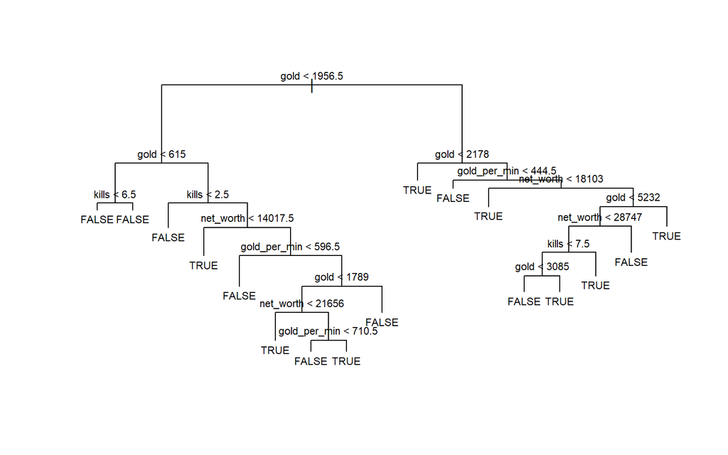

```r
plot(classTreeFit, show.node.label=TRUE)
text(classTreeFit,pretty=0,cex=0.7)
```

#### Pruning

We graphed the deviance drop as branches increased below by using cv.tree() which performs cross validation and prune.misclass which measures the deviance of a tree per branch. The graph below shows the minimum deviance associated to a branch, and thus the number of branches in a tree with least amount of deviance will be used to make predictions. This is one method to deal with over-fitting and variance from decision trees, the reduction of branches. One can see that higher number of branches can lead to higher deviance.

```r
pruneFit <- cv.tree(classTreeFit, FUN = prune.misclass)
summary(pruneFit)
```

```
##        Length Class  Mode
## size   6      -none- numeric
## dev    6      -none- numeric
## k      6      -none- numeric
## method 1      -none- character
```

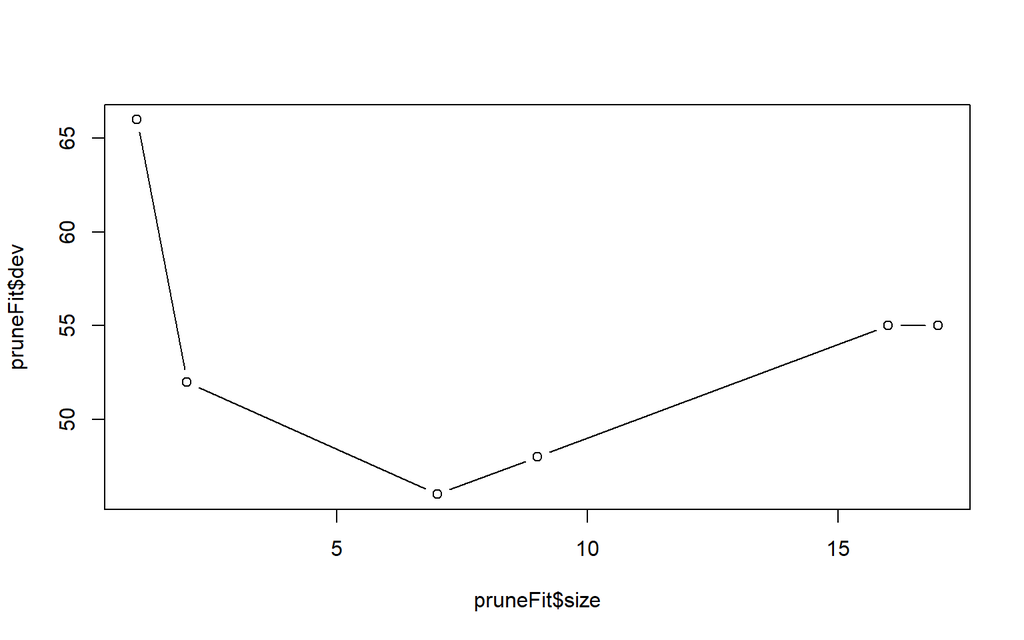

```r
#plot the accuracy of the predictions based on number of branches
plot(pruneFit$size, pruneFit$dev, type = "b")
```

```r
#pruneFit has two columns that indicate size of tree and deviation
#Here we combine the two, and order them such that the best size count is at the top
#We then take that top row value for size and set it to a variable to be used later to create the
#    final pruned tree
dfPruneFit <- cbind(size=pruneFit$size,dev=pruneFit$dev)
dfPruneFit <- data.frame(dfPruneFit)
dfPruneFit <- dfPruneFit %>% group_by(size)%>%arrange(size)%>%arrange(dev)
dfPruneFit
```

```
## # A tibble: 6 × 2
## # Groups:   size [6]
##    size   dev
##   <dbl> <dbl>
## 1     7    46
## 2     9    48
## 3     2    52
## 4    16    55
## 5    17    55
## 6     1    66
```

```r
bestVal <- dfPruneFit$size[1]
bestVal
```

```
## [1] 7
```

#### Predictions and Tree #1

Using our pruned predictions on the test data, below is our resulting decision tree. It is simple and clear, but as we will see it performs quite poorly. Residual mean deviance still remains high.

```r
#prune.misclass is a abbreviated form of prune.tree(method = "misclass") that takes a value 'k'
#    to create the tree with that number of branches
pruneFitFinal <- prune.misclass(classTreeFit, best = bestVal)
summary(pruneFitFinal)
```

```
##
## Classification tree:
## snip.tree(tree = classTreeFit, nodes = c(4L, 3L, 94L))
## Number of terminal nodes:  7
## Residual mean deviance:  0.8756 = 124.3 / 142
## Misclassification error rate: 0.1745 = 26 / 149
```

```r
prunePred <- predict(pruneFitFinal, dplyr::select(dataTest, -"win"), type = "class")

prunePred
```

```
##  [1] FALSE TRUE  TRUE  TRUE  TRUE  TRUE  TRUE  TRUE  TRUE  FALSE FALSE FALSE
## [13] FALSE TRUE  FALSE TRUE  TRUE  TRUE  TRUE  FALSE TRUE  TRUE  FALSE TRUE
## [25] FALSE TRUE  TRUE  FALSE TRUE  TRUE  TRUE  FALSE FALSE FALSE FALSE FALSE
## [37] TRUE  FALSE FALSE TRUE  TRUE  TRUE  TRUE  TRUE  TRUE  FALSE FALSE TRUE
## [49] TRUE
## Levels: FALSE TRUE
```

When creating a Confusion Matrix, we see accuracy is poor with sensitivity at middling levels.

```r
cm <- confusionMatrix(prunePred,dataTest$win)

cm
```

```
## Confusion Matrix and Statistics
##
##           Reference
## Prediction FALSE TRUE
##      FALSE    15    4
##      TRUE      7   23
##
##                Accuracy : 0.7755
##                  95% CI : (0.6338, 0.8823)
##     No Information Rate : 0.551
##     P-Value [Acc > NIR] : 0.0009468
##
##                   Kappa : 0.5405
##
##  Mcnemar's Test P-Value : 0.5464936
##
##             Sensitivity : 0.6818
##             Specificity : 0.8519
##          Pos Pred Value : 0.7895
##          Neg Pred Value : 0.7667
##              Prevalence : 0.4490
##          Detection Rate : 0.3061
##    Detection Prevalence : 0.3878
##       Balanced Accuracy : 0.7668
##
##        'Positive' Class : FALSE
##
```

Below we can see one of the strengths of Decision Trees, which is their interpretability.

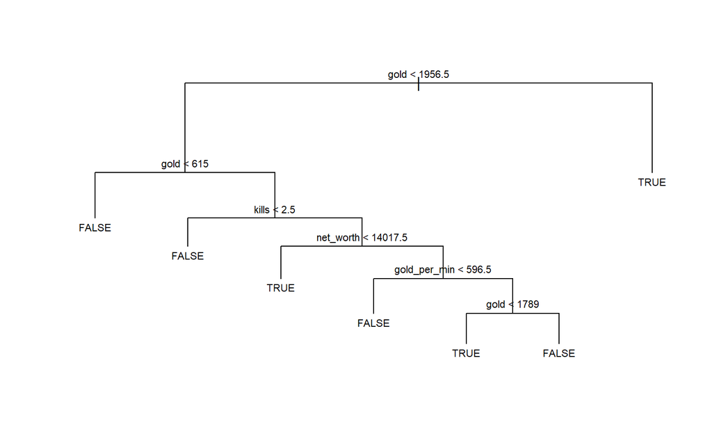

```r
plot(pruneFitFinal, show.node.label=TRUE)
text(pruneFitFinal,pretty=0,cex=0.7)
```

### Decision Tree #2

The second decision tree will use the tower damage, duration, lane, and lane role variables. Hopefully a better result is found and can be useful. Below is the data we are working with.

```r
#Create first set of variables
keepVars2 <- c("tower_damage","duration","lane","lane_role","win")

#Select only columns that match our set of variables
dataModel_sub2 <- dataModel[, names(dataModel) %in% keepVars2]
paged_table(dataModel_sub2) #Check our dataframe
```

| win | tower_damage | duration | lane | lane_role |
| --- | --- | --- | --- | --- |
| FALSE | 1221 | 1754 | 1 | 3 |
| FALSE | 1559 | 1794 | 1 | 3 |
| TRUE | 19823 | 1547 | 3 | 3 |
| FALSE | 1264 | 1319 | 1 | 1 |
| TRUE | 28469 | 2938 | 3 | 1 |
| TRUE | 10388 | 2435 | 3 | 1 |
| FALSE | 11727 | 1846 | 1 | 1 |
| FALSE | 6657 | 1315 | 3 | 3 |
| TRUE | 18541 | 2332 | 1 | 3 |
| TRUE | 9039 | 2263 | 3 | 3 |

[output cut: 188 more lines]

```r
#Subset based on indexes
dataTrain2 <- dataModel_sub2[dataIndex, ]
dataTest2 <- dataModel_sub2[-dataIndex, ]
```

When viewing our mean deviance, it seems to be notably better than the last tree. The mis-classification error rate is also quite low. As with the last tree, pruning will be performed and predictions made based on the number of branches that provide the lowest amount of deviance.

```r
classTreeFit2 <- tree(win ~ ., data = dataTrain2) # The '.' means all variables to be used as explanatory variables

summary(classTreeFit2)
```

```
##
## Classification tree:
## tree(formula = win ~ ., data = dataTrain2)
## Variables actually used in tree construction:
## [1] "tower_damage" "duration"     "lane_role"
## Number of terminal nodes:  11
## Residual mean deviance:  0.3649 = 50.35 / 138
## Misclassification error rate: 0.08725 = 13 / 149
```

#### Pruning

The graph below shows the number of ideal branches to minimize deviance and is selected for use.

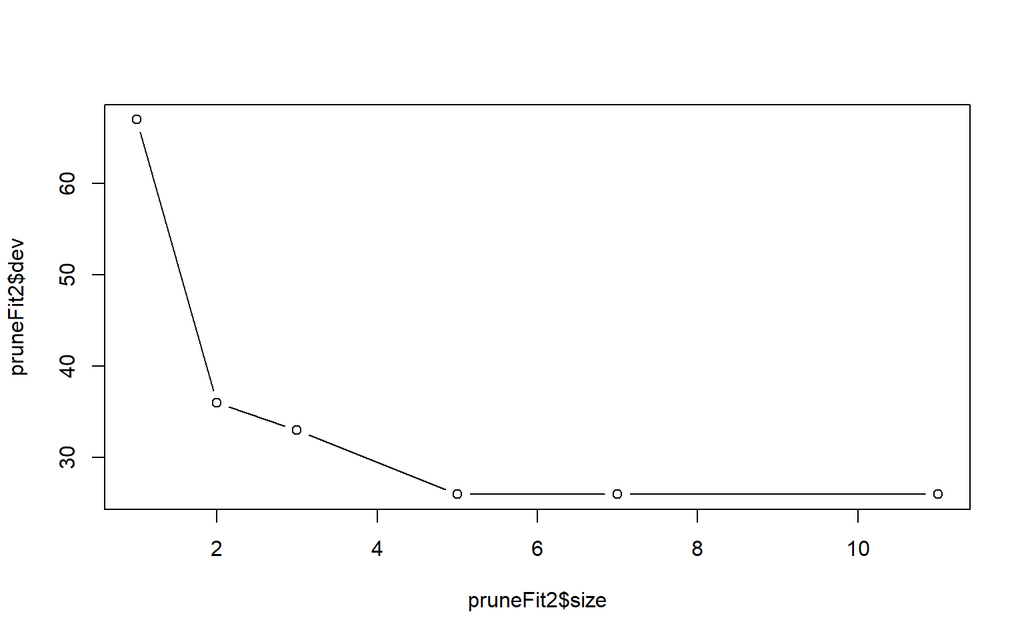

```r
#cv.tree will perform cross-fold validation
pruneFit2 <- cv.tree(classTreeFit2, FUN = prune.misclass)

#plot the accuracy of the predictions based on number of branches
plot(pruneFit2$size, pruneFit2$dev, type = "b")
```

```r
#pruneFit has two columns that indicate size of tree and deviation
#Here we combine the two, and order them such that the best size count is at the top
#We then take that top row value for size and set it to a variable to be used later to create the
#    final pruned tree
dfPruneFit2 <- cbind(size=pruneFit2$size,dev=pruneFit2$dev)
dfPruneFit2 <- data.frame(dfPruneFit2)
dfPruneFit2 <- dfPruneFit2 %>% group_by(size)%>%arrange(size)%>%arrange(dev)
dfPruneFit2
```

```
## # A tibble: 6 × 2
## # Groups:   size [6]
##    size   dev
##   <dbl> <dbl>
## 1     5    26
## 2     7    26
## 3    11    26
## 4     3    33
## 5     2    36
## 6     1    67
```

```r
#alternative method of choosing best method
#dfPruneFit2$size[which.min(dfPruneFit2$dev)]

bestVal2 <- dfPruneFit2$size[1]
```

#### Predictions and Tree #2

The residual mean deviance and mis-classification rate are notably improved from tree #1, highlighting one of the pitfalls of decision trees.

```r
#prune.misclass is a abbreviated form of prune.tree(method = "misclass") that takes a value 'k'
#    to create the tree with that number of branches
pruneFitFinal2 <- prune.misclass(classTreeFit2, best = bestVal2)
summary(pruneFitFinal2)
```

```
##
## Classification tree:
## snip.tree(tree = classTreeFit2, nodes = c(6L, 14L, 5L))
## Variables actually used in tree construction:
## [1] "tower_damage" "duration"
## Number of terminal nodes:  5
## Residual mean deviance:  0.5903 = 85 / 144
## Misclassification error rate: 0.1074 = 16 / 149
```

```r
prunePred2 <- predict(pruneFitFinal2, dplyr::select(dataTest2, -"win"), type = "class")

prunePred2
```

```
##  [1] FALSE FALSE TRUE  FALSE FALSE TRUE  TRUE  TRUE  TRUE  TRUE  FALSE TRUE
## [13] FALSE TRUE  FALSE FALSE TRUE  TRUE  FALSE FALSE TRUE  FALSE FALSE TRUE
## [25] FALSE TRUE  TRUE  FALSE TRUE  FALSE FALSE FALSE FALSE TRUE  TRUE  FALSE
## [37] TRUE  FALSE FALSE FALSE FALSE FALSE TRUE  TRUE  FALSE TRUE  FALSE TRUE
## [49] TRUE
## Levels: FALSE TRUE
```

This decision tree performs similarly when observing the Confusion Matrix.

```r
cm2 <- confusionMatrix(prunePred2,dataTest2$win)

cm2
```

```
## Confusion Matrix and Statistics
##
##           Reference
## Prediction FALSE TRUE
##      FALSE    19    7
##      TRUE      3   20
##
##                Accuracy : 0.7959
##                  95% CI : (0.6566, 0.8976)
##     No Information Rate : 0.551
##     P-Value [Acc > NIR] : 0.000311
##
##                   Kappa : 0.5944
##
##  Mcnemar's Test P-Value : 0.342782
##
##             Sensitivity : 0.8636
##             Specificity : 0.7407
##          Pos Pred Value : 0.7308
##          Neg Pred Value : 0.8696
##              Prevalence : 0.4490
##          Detection Rate : 0.3878
##    Detection Prevalence : 0.5306
##       Balanced Accuracy : 0.8022
##
##        'Positive' Class : FALSE
##
```

The final tree looks like below.

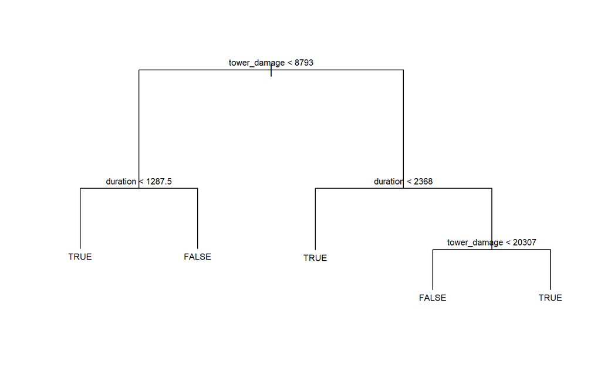

```r
plot(pruneFitFinal2, show.node.label=TRUE)
text(pruneFitFinal2,pretty=0,cex=0.7)
```

## RPart Comparison

RPart is used below to create and show other standard variance measurements seen with Decision Trees other than deviance. ROC, Sensitivity, and Specificity are all relatively acceptable levels. The ROC curve is a graphical representation of the model’s ability to distinguish between the positive and negative classes across different probability thresholds. Sensitivity measures the proportion of actual positive cases that the model correctly predicts as positive. Specificity is the same as Sensitivity but for negative cases. Specificity and Sensitivity are shown in the Confusion Matrix tables with the other methods.

```r
#we change some factor levels so that caret's train function does not have issues
levels(dataTrain2$lane) <- c("Safelane", "Mid","Offlane","Roam","Safelane Support")
levels(dataTrain2$lane_role) <- c("Carry","Mid","Offlane","Roam")
levels(dataTrain2$win) <- c("Lose","Win")

ctrl <- trainControl(method = "cv", number = 10, summaryFunction = twoClassSummary, classProbs = TRUE)
model <- train(win ~ ., data = dataTrain2, method = "rpart", trControl = ctrl)
print(model)
```

```
## CART
##
## 149 samples
##   4 predictor
##   2 classes: 'Lose', 'Win'
##
## No pre-processing
## Resampling: Cross-Validated (10 fold)
## Summary of sample sizes: 134, 134, 135, 134, 135, 135, ...
## Resampling results across tuning parameters:
##
##   cp          ROC        Sens       Spec
##   0.06818182  0.7977348  0.7119048  0.8541667
##   0.12121212  0.7321429  0.7119048  0.7902778
##   0.51515152  0.5339286  0.1428571  0.9250000
##
## ROC was used to select the optimal model using the largest value.
## The final value used for the model was cp = 0.06818182.
```

```r
model$bestTune
```

```
##           cp
## 1 0.06818182
```

```r
best_cp <- model$bestTune
```